# Netflix Show Analysis

With the rise of streaming services, Netflix has become a global leader in delivering on-demand entertainment. As the platform's content library expands, understanding the characteristics of its shows and movies is crucial for both content creators and viewers. This analysis dives into a Netflix dataset to explore the types of content offered, their release patterns, and the global reach of the platform.

In this notebook, we will examine Netflix shows and movies, analyzing key aspects such as their genres, countries of origin, release years, and ratings. The dataset includes information such as show titles, directors, cast members, duration, and descriptions. Our goal is to answer important questions like:

1. What are the most common types of content on Netflix (movies vs. TV shows)?
2. Which countries contribute the most content to Netflix’s library?
3. What are the most frequent genres, and how has their popularity changed over time?
4. How do content ratings vary across different regions and types of shows?
5. Who are the most frequently featured directors and actors in Netflix content?
6. Which titles have the longest or shortest durations?

The analysis begins by loading the dataset and exploring its structure to gain a preliminary understanding of the variables and their distributions.

## Importing Libraries and Dataset

```python
import pandas as pd
import numpy as np
import matplotlib.pyplot as plt
import seaborn as sns
```

```python
df = pd.read_csv('netflix_titles.csv')
```

```python
df.columns
```

```
Index(['show_id', 'type', 'title', 'director', 'cast', 'country', 'date_added',
       'release_year', 'rating', 'duration', 'listed_in', 'description'],
      dtype='object')
```

```python
df.head()
```

|  | show_id | type | title | director | cast | country | date_added | release_year | rating | duration | listed_in | description |
| --- | --- | --- | --- | --- | --- | --- | --- | --- | --- | --- | --- | --- |
| 0 | s1 | Movie | Dick Johnson Is Dead | Kirsten Johnson | NaN | United States | September 25, 2021 | 2020 | PG-13 | 90 min | Documentaries | As her father nears the end of his life, filmm... |
| 1 | s2 | TV Show | Blood & Water | NaN | Ama Qamata, Khosi Ngema, Gail Mabalane, Thaban... | South Africa | September 24, 2021 | 2021 | TV-MA | 2 Seasons | International TV Shows, TV Dramas, TV Mysteries | After crossing paths at a party, a Cape Town t... |
| 2 | s3 | TV Show | Ganglands | Julien Leclercq | Sami Bouajila, Tracy Gotoas, Samuel Jouy, Nabi... | NaN | September 24, 2021 | 2021 | TV-MA | 1 Season | Crime TV Shows, International TV Shows, TV Act... | To protect his family from a powerful drug lor... |
| 3 | s4 | TV Show | Jailbirds New Orleans | NaN | NaN | NaN | September 24, 2021 | 2021 | TV-MA | 1 Season | Docuseries, Reality TV | Feuds, flirtations and toilet talk go down amo... |
| 4 | s5 | TV Show | Kota Factory | NaN | Mayur More, Jitendra Kumar, Ranjan Raj, Alam K... | India | September 24, 2021 | 2021 | TV-MA | 2 Seasons | International TV Shows, Romantic TV Shows, TV ... | In a city of coaching centers known to train I... |

## Cleaning the dataset

### 1) Removing Duplicatees

```python
df.drop_duplicates(inplace=True)
```

```python
df.columns
```

```
Index(['show_id', 'type', 'title', 'director', 'cast', 'country', 'date_added',
       'release_year', 'rating', 'duration', 'listed_in', 'description'],
      dtype='object')
```

```python
df.isnull().sum()
```

```
show_id            0
type               0
title              0
director        2634
cast             825
country          831
date_added        10
release_year       0
rating             4
duration           3
listed_in          0
description        0
dtype: int64
```

### 2) Handling Null Values

```python
df['director'].fillna('Unknown', inplace=True)
df['cast'].fillna('Unknown', inplace=True)
df['country'].fillna('Unknown', inplace=True)
df['duration'].fillna('Unknown', inplace=True)
df['rating'].fillna('Unrated', inplace=True)
df['date_added'].fillna(df['date_added'].mode, inplace=True)
```

## Analyzing the Dataset

### 1) What are the most common types of content on Netflix (movies vs. TV shows)?

```python
df_type_count = pd.DataFrame(df['type'].value_counts()).reset_index()
```

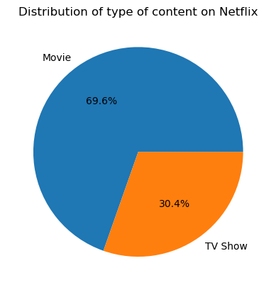

```python
plt.pie(df_type_count['count'], labels=df_type_count['type'], autopct='%1.1f%%')
plt.title('Distribution of type of content on Netflix')
plt.show()
```

### 2) Which countries contribute the most content to Netflix’s library?

```python
top_countries = pd.DataFrame(df.groupby('country')['type'].agg('count')).reset_index().sort_values(by='type',ascending=False).head(10)
```

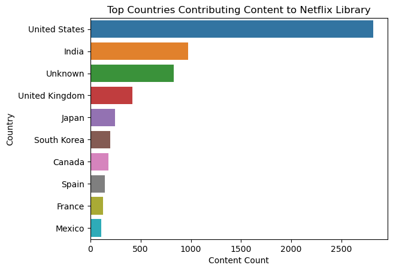

```python
sns.barplot(data=top_countries, x='type', y='country')
plt.xlabel('Content Count')
plt.ylabel('Country')
plt.title("Top Countries Contributing Content to Netflix Library")
plt.show()
```

The United States provides the largest share of content in the Netflix library, with India coming in second.